# Tarea 4 Genómica Funcional 2025

Lilith Martinez A.

12 abril, 2025

# 1 Tarea 4

## 1.1 (20 %) Preguntas rápidas (simples)

1. Considera una red de 15 nodos . Considera que tienes una sola conexión. ¿Cuál es el número máximo de nodos que puedes conectar? Dado un solo nodo , ¿cuál es el número máximo conexiones que puede tener tal nodo?

```
c(a,b)
```

```
[1] 105  14
```

2. Considera una red dirigida de 10 nodos. Usa 25 conexiones y dibuja una red con ese número de nodos y conexiones dirigidas. Calcula la distribución de conectividades de salida.Calcula el número total de conexiones de salida ¿Cómo se compara el número total de de conectividades de entrada (son iguales, diferentes)? Explica tu respuesta. Calcula el promedio de entrada y de salida. Discute tu resultado.

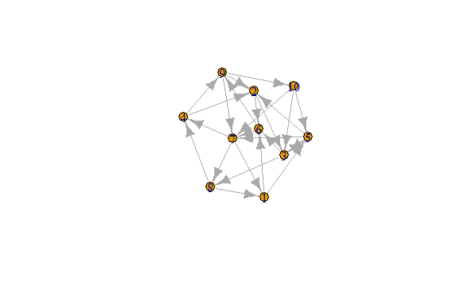

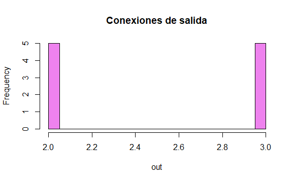

```
# Total de conexiones out e in
T_conex <- c(sum(out), sum(degree(red_dir, mode = "in")))
T_conex
```

```
[1] 25 25
```

Son iguales, debido a que las mismas conexiones que van de salida de los nodo son las mismas que van dirigas/entran a otros.

```
# Promedio de in y out
promedios <- c(mean(out), mean(degree(red_dir, mode = "in")))
promedios
```

```
[1] 2.5 2.5
```

Este tambien resulta ser igual porque conserva la misma caracteristica y, por lo tanto, consideran excatamente la misma cantidad de conexiones.

3. Considera una red no dirigida de $n=3,4,5,6$ nodos respectivamente. ¿Cuál es el número máximo de conexiones que puedes poner? Dibuja cada caso. ¿Qué pasa si la red es dirigida?

```
# Dibujos
for (name in names(redes)) {
  cat("\nRed de", name, "\n")
  red <- redes[[name]]
  cat("\nNuero max. de conexiones:", c_max(red), "\n")
  plot(red, main= "Red NO dirigida")
}
```

```
Red de nd3

Nuero max. de conexiones: 3

Red de nd4

Nuero max. de conexiones: 6
```

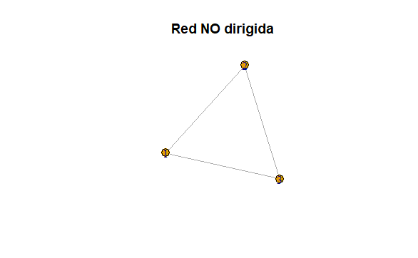

```
Red de nd5

Nuero max. de conexiones: 10
```

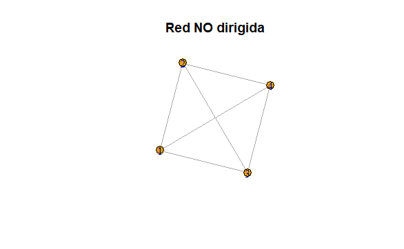

```
Red de nd6

Nuero max. de conexiones: 15
```

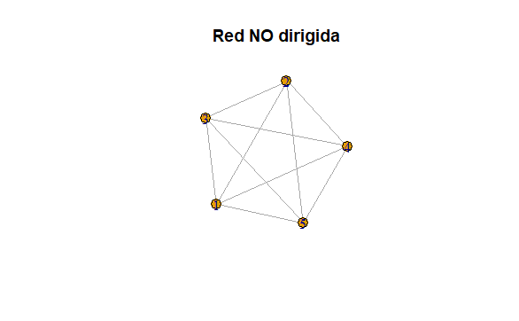

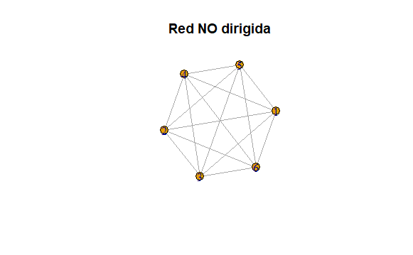

```
# Dibujos
for (name in names(redes_d)) {
  cat("\nRed de", name, "\n")
  red_d <- redes_d[[name]]
  plot(red_d, main= "Red dirigida")
}
```

```
Red de nd3_d

Red de nd4_d
```

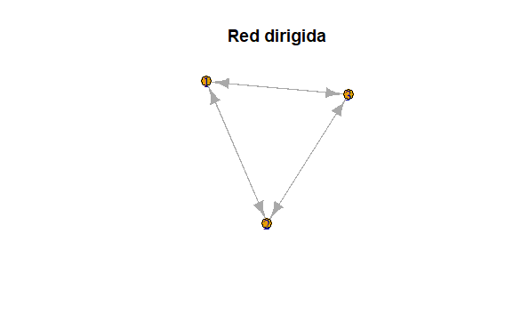

```
Red de nd5_d
```

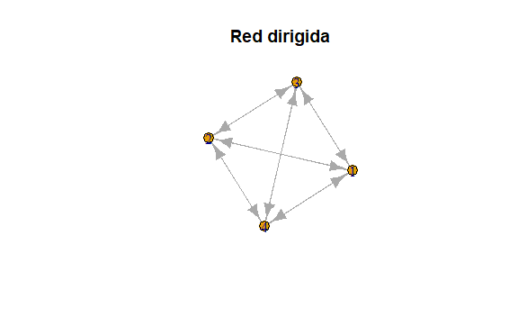

```
Red de nd6_d
```

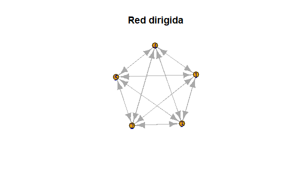

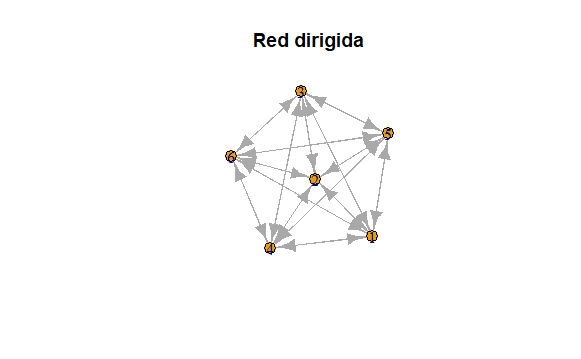

4. Considera tu red de amigos reales. ¿Cuál es tu coeficiente de clusterización?

```
transitivity(red_amigos, type = "local")["TRINIDAD"]
```

```
TRINIDAD
       1
```

## 1.2 (80 % ) Scripts, código, texto y gráficas

1. **Propiedades básicas de redes**

A partir de las siguientes redes calcula manualmente las siguientes propiedades de cada red

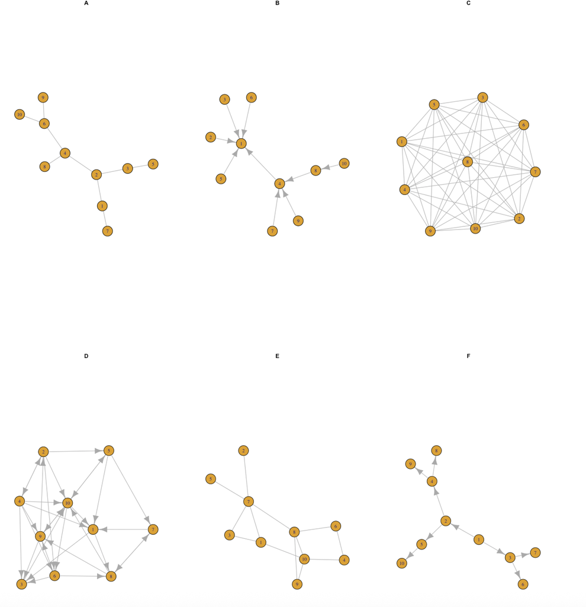

- Número de conexiones
- Número de nodos
- Degree
- Average degree
- Degree distribution
- Density
- Adjacency matrix
- Matriz de distancia
- Diámetro
- Nodos más distantes
- Coeficiente de clusterización

Después escribe código en R que genere las gráficas de las redes y que calcule las propiedades anteriores para cada red.

```
for (name in names(redes_AF)) {

  cat("\nImagen de la", name, "\n")
  red <- redes_AF[[name]]
  plot(red, main= name)

  cat("\nNúmero de conexiones:", gsize(red), "\n")
  cat("\nNúmero de nodos:", gorder(red), "\n")
  cat("\nDegree local:", degree(red, mode = "total"), "\n")
  cat("\nPromedio del degree:", mean(degree(red, mode = "total")), "\n")

  # Degree distribution
  dd <- degree_distribution(red)
  barplot(dd, main='Distribucion del degree', ylim = c(0:1), col='red', ylab = "Pk", xlab = "K")

  cat("\nDensidad:", edge_density(red), "\n")

  cat("\nMatriz de adyacencia de la", name, "\n")
  print(as_adjacency_matrix(red))

  cat("\nMatriz de distancias de la", name, "\n")
  print(distances(red))

  cat("\nDiámetro:", diameter(red), "\n")
  # cat("\n", name, "\n") # Nodos más distantes
  cat("\nCoeficiente de clusterización local:", transitivity(red, type = "local"), "\n")
  cat("\nCoeficiente de clusterización", transitivity(red, type = "global" ), "\n")

}
```

```
Imagen de la redA

Número de conexiones: 9

Número de nodos: 10

Degree local: 2 3 2 3 1 3 1 1 1 1

Promedio del degree: 1.8
```

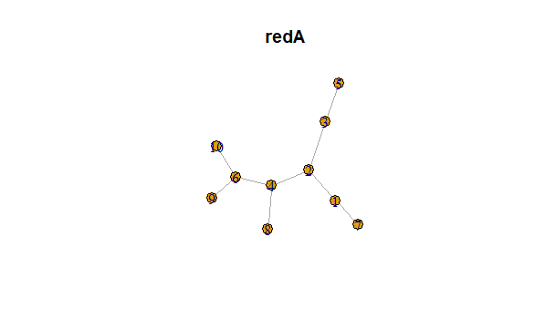

```
Densidad: 0.2

Matriz de adyacencia de la redA
10 x 10 sparse Matrix of class "dgCMatrix"

 [1,] . 1 . . . . 1 . . .
 [2,] 1 . 1 1 . . . . . .
 [3,] . 1 . . 1 . . . . .
 [4,] . 1 . . . 1 . 1 . .
 [5,] . . 1 . . . . . . .
 [6,] . . . 1 . . . . 1 1
 [7,] 1 . . . . . . . . .
 [8,] . . . 1 . . . . . .
 [9,] . . . . . 1 . . . .
[10,] . . . . . 1 . . . .

Matriz de distancias de la redA
      [,1] [,2] [,3] [,4] [,5] [,6] [,7] [,8] [,9] [,10]
 [1,]    0    1    2    2    3    3    1    3    4     4
 [2,]    1    0    1    1    2    2    2    2    3     3
 [3,]    2    1    0    2    1    3    3    3    4     4
 [4,]    2    1    2    0    3    1    3    1    2     2
 [5,]    3    2    1    3    0    4    4    4    5     5
 [6,]    3    2    3    1    4    0    4    2    1     1
 [7,]    1    2    3    3    4    4    0    4    5     5
 [8,]    3    2    3    1    4    2    4    0    3     3
 [9,]    4    3    4    2    5    1    5    3    0     2
[10,]    4    3    4    2    5    1    5    3    2     0

Diámetro: 5

Coeficiente de clusterización local: 0 0 0 0 NaN 0 NaN NaN NaN NaN

Coeficiente de clusterización 0

Imagen de la redB
```

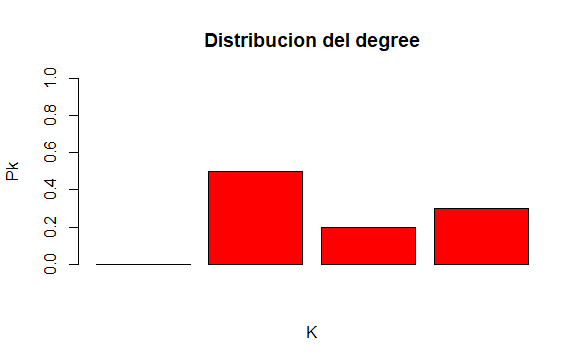

```
Número de conexiones: 9

Número de nodos: 10

Degree local: 5 1 1 4 1 1 1 2 1 1

Promedio del degree: 1.8
```

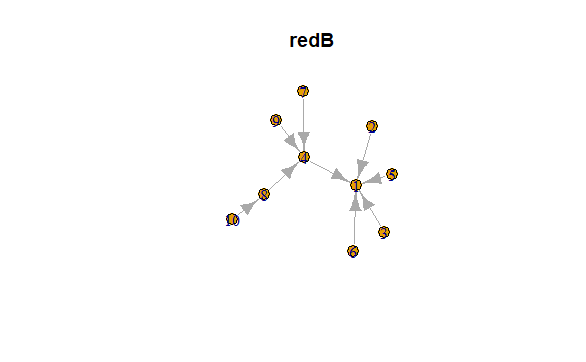

```
Densidad: 0.1

Matriz de adyacencia de la redB
10 x 10 sparse Matrix of class "dgCMatrix"

 [1,] . . . . . . . . . .
 [2,] 1 . . . . . . . . .
 [3,] 1 . . . . . . . . .
 [4,] 1 . . . . . . . . .
 [5,] 1 . . . . . . . . .
 [6,] 1 . . . . . . . . .
 [7,] . . . 1 . . . . . .
 [8,] . . . 1 . . . . . .
 [9,] . . . 1 . . . . . .
[10,] . . . . . . . 1 . .

Matriz de distancias de la redB
      [,1] [,2] [,3] [,4] [,5] [,6] [,7] [,8] [,9] [,10]
 [1,]    0    1    1    1    1    1    2    2    2     3
 [2,]    1    0    2    2    2    2    3    3    3     4
 [3,]    1    2    0    2    2    2    3    3    3     4
 [4,]    1    2    2    0    2    2    1    1    1     2
 [5,]    1    2    2    2    0    2    3    3    3     4
 [6,]    1    2    2    2    2    0    3    3    3     4
 [7,]    2    3    3    1    3    3    0    2    2     3
 [8,]    2    3    3    1    3    3    2    0    2     1
 [9,]    2    3    3    1    3    3    2    2    0     3
[10,]    3    4    4    2    4    4    3    1    3     0

Diámetro: 3

Coeficiente de clusterización local: 0 NaN NaN 0 NaN NaN NaN 0 NaN NaN

Coeficiente de clusterización 0

Imagen de la redC
```

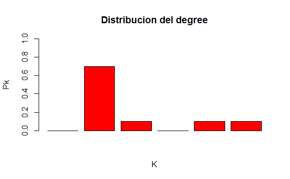

```
Número de conexiones: 45

Número de nodos: 10

Degree local: 9 9 9 9 9 9 9 9 9 9

Promedio del degree: 9
```

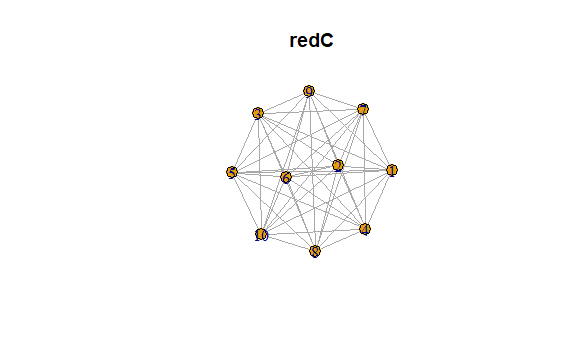

```
Densidad: 1

Matriz de adyacencia de la redC
10 x 10 sparse Matrix of class "dgCMatrix"

 [1,] . 1 1 1 1 1 1 1 1 1
 [2,] 1 . 1 1 1 1 1 1 1 1
 [3,] 1 1 . 1 1 1 1 1 1 1
 [4,] 1 1 1 . 1 1 1 1 1 1
 [5,] 1 1 1 1 . 1 1 1 1 1
 [6,] 1 1 1 1 1 . 1 1 1 1
 [7,] 1 1 1 1 1 1 . 1 1 1
 [8,] 1 1 1 1 1 1 1 . 1 1
 [9,] 1 1 1 1 1 1 1 1 . 1
[10,] 1 1 1 1 1 1 1 1 1 .

Matriz de distancias de la redC
      [,1] [,2] [,3] [,4] [,5] [,6] [,7] [,8] [,9] [,10]
 [1,]    0    1    1    1    1    1    1    1    1     1
 [2,]    1    0    1    1    1    1    1    1    1     1
 [3,]    1    1    0    1    1    1    1    1    1     1
 [4,]    1    1    1    0    1    1    1    1    1     1
 [5,]    1    1    1    1    0    1    1    1    1     1
 [6,]    1    1    1    1    1    0    1    1    1     1
 [7,]    1    1    1    1    1    1    0    1    1     1
 [8,]    1    1    1    1    1    1    1    0    1     1
 [9,]    1    1    1    1    1    1    1    1    0     1
[10,]    1    1    1    1    1    1    1    1    1     0

Diámetro: 1

Coeficiente de clusterización local: 1 1 1 1 1 1 1 1 1 1

Coeficiente de clusterización 1

Imagen de la redD
```

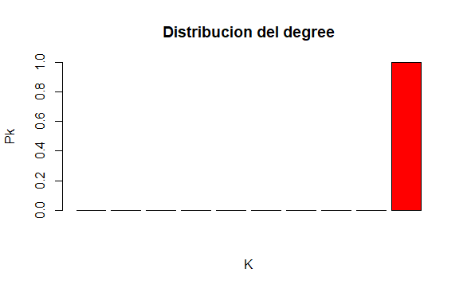

```
Número de conexiones: 31

Número de nodos: 10

Degree local: 6 6 5 7 5 6 4 6 7 10

Promedio del degree: 6.2
```

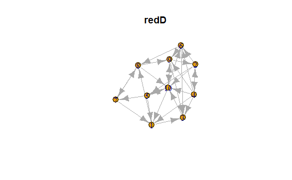

```
Densidad: 0.3444444

Matriz de adyacencia de la redD
10 x 10 sparse Matrix of class "dgCMatrix"

 [1,] . . 1 . . . . 1 . .
 [2,] . . . 1 1 1 . . . 1
 [3,] . . . . . . . . . 1
 [4,] 1 1 1 . . 1 . . 1 1
 [5,] 1 . . . . . 1 . . 1
 [6,] . . 1 . . . . 1 1 .
 [7,] 1 . . . . . . 1 . .
 [8,] . . . . . . 1 . 1 1
 [9,] . 1 1 . . . . . . 1
[10,] 1 . . . 1 1 . . 1 .

Matriz de distancias de la redD
      [,1] [,2] [,3] [,4] [,5] [,6] [,7] [,8] [,9] [,10]
 [1,]    0    2    1    1    1    2    1    1    2     1
 [2,]    2    0    2    1    1    1    2    2    1     1
 [3,]    1    2    0    1    2    1    2    2    1     1
 [4,]    1    1    1    0    2    1    2    2    1     1
 [5,]    1    1    2    2    0    2    1    2    2     1
 [6,]    2    1    1    1    2    0    2    1    1     1
 [7,]    1    2    2    2    1    2    0    1    2     2
 [8,]    1    2    2    2    2    1    1    0    1     1
 [9,]    2    1    1    1    2    1    2    1    0     1
[10,]    1    1    1    1    1    1    2    1    1     0

Diámetro: 4

Coeficiente de clusterización local: 0.4666667 0.7 0.8 0.7333333 0.5 0.7333333 0.6666667 0.5 0.7333333 0.5714286

Coeficiente de clusterización 0.6377953

Imagen de la redE
```

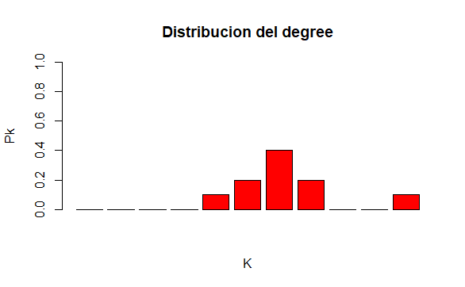

```
Número de conexiones: 13

Número de nodos: 10

Degree local: 3 1 2 2 1 2 5 4 2 4

Promedio del degree: 2.6
```

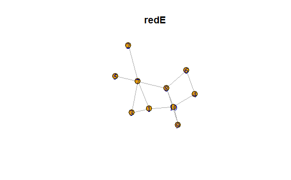

```
Densidad: 0.2888889

Matriz de adyacencia de la redE
10 x 10 sparse Matrix of class "dgCMatrix"

 [1,] . . 1 . . . 1 . . 1
 [2,] . . . . . . 1 . . .
 [3,] 1 . . . . . 1 . . .
 [4,] . . . . . 1 . . . 1
 [5,] . . . . . . 1 . . .
 [6,] . . . 1 . . . 1 . .
 [7,] 1 1 1 . 1 . . 1 . .
 [8,] . . . . . 1 1 . 1 1
 [9,] . . . . . . . 1 . 1
[10,] 1 . . 1 . . . 1 1 .

Matriz de distancias de la redE
      [,1] [,2] [,3] [,4] [,5] [,6] [,7] [,8] [,9] [,10]
 [1,]    0    2    1    2    2    3    1    2    2     1
 [2,]    2    0    2    4    2    3    1    2    3     3
 [3,]    1    2    0    3    2    3    1    2    3     2
 [4,]    2    4    3    0    4    1    3    2    2     1
 [5,]    2    2    2    4    0    3    1    2    3     3
 [6,]    3    3    3    1    3    0    2    1    2     2
 [7,]    1    1    1    3    1    2    0    1    2     2
 [8,]    2    2    2    2    2    1    1    0    1     1
 [9,]    2    3    3    2    3    2    2    1    0     1
[10,]    1    3    2    1    3    2    2    1    1     0

Diámetro: 4

Coeficiente de clusterización local: 0.3333333 NaN 1 0 NaN 0 0.1 0.1666667 1 0.1666667

Coeficiente de clusterización 0.2068966

Imagen de la redF
```

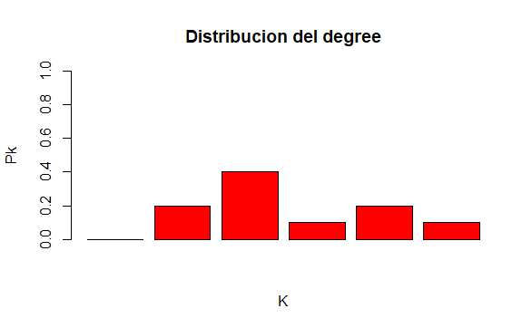

```
Número de conexiones: 9

Número de nodos: 10

Degree local: 2 3 3 3 2 1 1 1 1 1

Promedio del degree: 1.8
```

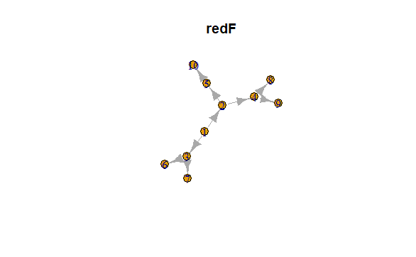

```
Densidad: 0.1

Matriz de adyacencia de la redF
10 x 10 sparse Matrix of class "dgCMatrix"

 [1,] . 1 1 . . . . . . .
 [2,] . . . 1 1 . . . . .
 [3,] . . . . . 1 1 . . .
 [4,] . . . . . . . 1 1 .
 [5,] . . . . . . . . . 1
 [6,] . . . . . . . . . .
 [7,] . . . . . . . . . .
 [8,] . . . . . . . . . .
 [9,] . . . . . . . . . .
[10,] . . . . . . . . . .

Matriz de distancias de la redF
      [,1] [,2] [,3] [,4] [,5] [,6] [,7] [,8] [,9] [,10]
 [1,]    0    1    1    2    2    2    2    3    3     3
 [2,]    1    0    2    1    1    3    3    2    2     2
 [3,]    1    2    0    3    3    1    1    4    4     4
 [4,]    2    1    3    0    2    4    4    1    1     3
 [5,]    2    1    3    2    0    4    4    3    3     1
 [6,]    2    3    1    4    4    0    2    5    5     5
 [7,]    2    3    1    4    4    2    0    5    5     5
 [8,]    3    2    4    1    3    5    5    0    2     4
 [9,]    3    2    4    1    3    5    5    2    0     4
[10,]    3    2    4    3    1    5    5    4    4     0

Diámetro: 3

Coeficiente de clusterización local: 0 0 0 0 0 NaN NaN NaN NaN NaN

Coeficiente de clusterización 0
```

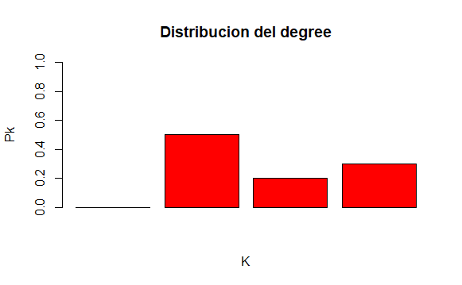

1. **Karate**

Considera la red del club de Karate de Zachary. [Acá](https://en.wikipedia.org/wiki/Zachary%27s_karate_club) puedes leer sobre eso. En igraph la gráfica está precargada

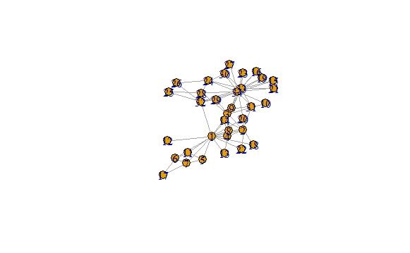

- ¿Cuántos nodos y conexiones tiene?
- ¿Quiénes son los nodos y cuál es la regla de conexión?
- ¿Qué tan densa es la red?
- ¿Cómo obtienes la matriz de adyacencia?
- ¿Es una red dirigida, pesada?
- Calcula y gráfica la distribución de conectividades
- Calcula el diámetro, la matriz de distancias y la distancia promedio
- Encuentra la trayectoria de los nodos más alejados.
- Existen nodos con coefeiciente de clusterización 1. ¿Qué significa?
- Mide, con al menos tres medidas de centralidad, los nodos más importantes.

```
which(
  degree(karate) >= sort(degree(karate), decreasing = TRUE)[5] &
    betweenness(karate) >= sort(betweenness(karate), decreasing = TRUE)[5] &
    closeness(karate) >= sort(closeness(karate), decreasing = TRUE)[5]
)
```

```
[1]  1  3 33 34
```

- ¿Cómo obtienes la matriz de adyacencia? Se realiza en base a la conexiones que tienen cada nodo con el resto. Para estos se usa una matriz binaria de 0 y 1, donde el 0 indica que na hay conexion y el 1 que si la hay.
- ¿Es una red dirigida, pesada? No, es una red no dirigida por lo que tampoco es ponderada.
- Existen nodos con coefeiciente de clusterización 1. ¿Qué significa? Que todos los nodos vecinos, respecto a un nodo, estan conectados entre si.
2. **Amigues**

A partir de la red de amigues que vimos en clase, en su versión no ponderada, contesta lo siguiente:

- Escribe una función que calcule el número de amigos que tiene cualquier persona arbitraria y lo compare con el número de los amigos de estos.

```
num_amigos(red_amigos, "TRINIDAD") # Ej
```

```
[[1]]
[1] "BLANCA" "3"

[[2]]
[1] "ISABEL" "9"

[[3]]
[1] "JULIETA" "7"

[[4]]
[1] "TRINIDAD" "3"
```

- Encuentra las dos personas más populares.

```
#Personas que se consideran muy populares
sort(degree(red_amigos, mode = "out"), decreasing = TRUE)[1:2]
```

```
  ZAID ISABEL
    16      9
```

3. **Red PPI**

A partir de la red de interacción proteína-proteína (PPI) de la levadura que se encuentra en la bilbioteca `igraphdata` Elabora un script que conteste lo siguiente:

- Encuentre qué tipo de distribución de conectividades tiene. Haz un ajuste en log-log para ver que tipo de distribución podría ser.
- Encuentra las diez proteínas más conectadas
- Calcula el diámetro y promedio de las distancias
- Crea una función que, a partir de eliminar al azar un noodo de la red genere el promedio d elas distancias después de eliminar $n=1,2,3,\ldots, 100$ nodos al azar
- Crea una función que elimine las proteínas más conectadas y calcule el promedio de las distancias cad vez que se remueve un nodo.
- Calcula el proemdio del coeficiente de clusterización. ¿Hay proteínas que tengan un coeficiente de clusterización de 1? Eso qué significa. Todas las proteinas que interaccionan/conectan con una proteina en especifico al mismo tiempo tambien esas interaccionan entre si.

4. **Redes biológicas**

Ve a al [Network Repository](https://networkrepository.com/bn-mouse-visual-cortex-1.php) y descarga la red en formato lista de adyacencia. Explica que representan los nodos y las conectividades.

Escribe código que resuelva lo siguiente:

- Cargue y genere una gráfica en `igraph`.
- Genera la gráfica con todos los layouts disponibles.
- Grafica la red con al menos tres medidas de centralidad.

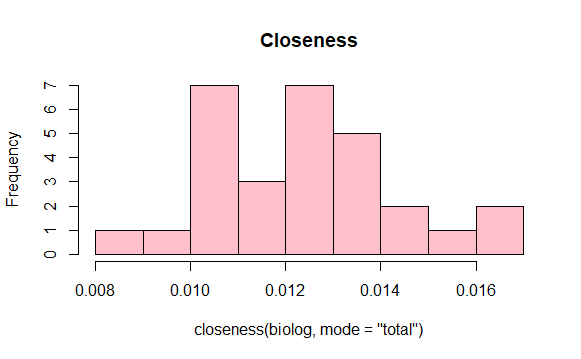

```
c
```

```
[1] 0.02222222
```

5. **Red de coexpresión simulada**

Simula una matriz de expresión con 20 genes en 6 condiciones diferentes.

```
expresion
```

```
   T1 T2 T3 T4 T5 T6
1  10  9  8  3  4  5
2   4  4  1  2  5  5
3   1  3  3  8  5  5
4   5  9  7  6  2  9
5   5  4  6  3  9  7
6   9  5  3  1  3 10
7   9  1  6  5  9  2
8   6  5  9  1  2  6
9   4  4  2 10  5  3
10  5  4  8  3  9  8
11  6  7  8  4  4  1
12  1  4  8 10  5  6
13  7  1  5  8  6 10
14  1  7  1  5  9  9
15  2  7  7  9 10  2
16  1  6 10  6  7  1
17  7  4  1  1  4 10
18  1  8  7  4  9  6
19  8  6  1 10  3 10
20  1  4  2  1  9  9
```

- Calcula la correlación entre todos los pares de genes
- Construye una red de coexpresión utilizando un umbral de correlación > 0.8.
- Calcula la distribución de grados.
- Identifica si hay módulos o agrupamientos de genes altamente correlacionados.
- Visualiza la red y discute qué tipo de topología tiene.

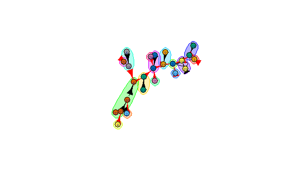

6. **Comparación de redes**

Construye dos redes: - Una red aleatoria tipo Erdos-Rényi. - Una red tipo “scale-free” usando el modelo Barabási–Albert.

Para ambas redes: - Compara su grado promedio, distribución de grados, coeficiente de clusterización y diámetro.

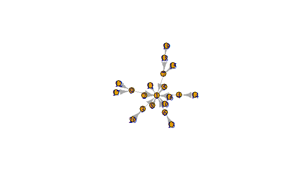

- Interpreta las diferencias en el contexto de redes biológicas.